# 3D Superresolution

In order to improve the accuracy of segmentation algorithms and interpretability of SBF-SEM datasets, we perform 3D axial superresolution.

One of the practical concerns with the major breakthroughs in deep superresolution is that the networks require ground truth volumes or images to train the network. However, because of the limits of our imaging modalities, we cannot obtain volumetric samples without axial decimation. However, the advantage of SBF-SEM is high resolution in the lateral plane.

We used the ADAM optimizer with a learning rate of `1e^-3` to train the network. We use relu activation functions throughout the entire network. During training, we took `1x800x800` px samples of our training platelet dataset, and preformed un-filtered decimation to produce `1x200x800` samples to form training-test pairs. We then upsampled the training set via bicubic interpolation (as per Dong et.al) to yield a `1x800x800` volume which we then feed through the network.

To perform inference and generate an isotropic volume, we first transpose our inference set to yield a volume of shape `800x50x800`, from which we take `1x50x800` samples from, perform bicubic interpolation to generate a `1x200x800` images. We then use these as inputs to the network, and then reconstruct and transpose the output to yield a final, isotropic volume of shape `200x800x800`.

We trained the network to minimize a mean squared error objective function, equivalent to maximizing peak signal-to-noise ratio (PSNR)

```python
# Imports
import os
import sys
sys.path.append("..") # Adds higher directory to python modules path.
import warnings
warnings.filterwarnings("ignore")

import numpy as np
import scipy
import tifffile as tif
from IPython.display import Image
import matplotlib.pyplot as plt

try:
    from skimage.metrics import peak_signal_noise_ratio as psnr
except ImportError:
    from skimage.measure import compare_psnr as psnr

from utils.utils import sort_alphanumeric

# Root project directory relative to this file
lcimb_dir = os.path.join("..", "..", "..", "..")
# Use platelet data test volume (ground truth to compute PSNR)
data_dir = os.path.join(lcimb_dir, "data/platelet")
test_volume = tif.imread(os.path.join(data_dir, "test-volume.tif"))

datapath = "../3D/data"
traindir = os.path.join(datapath, "train")

# helper functions
def show_data(z, title, fignum, figsize):
    # Display a sample of the image
    fig  = plt.figure(figsize=figsize)
    plt.imshow(z, cmap='gray')
    plt.title(title+': fig.'+ fignum)
    plt.show()
```

## Quantitative Results

In order to benchmark the performance of the 3D SRCNN on the platelet dataset, we also perform 3D superresolution via the three most common non-neural techniques: nearest neighbours, bilinear and bicubic interpolation.

```python
def spline_interp(order, fpath, scale):

    vol_interp = []
    for f in sort_alphanumeric(os.listdir(fpath)):

        block = tif.imread(os.path.join(fpath, f))
        block_interp = scipy.ndimage.zoom(block, (1, scale, 1), order=order)
        vol_interp.append(block_interp)

    vol_interp = np.array(vol_interp)
    vol_interp = np.squeeze(vol_interp)

    return vol_interp

# using the decimated training set to compute baseline metrics
traindir_data = os.path.join(traindir, "train")
neighbours = spline_interp(0, traindir_data, 4)
bilinear = spline_interp(1, traindir_data, 4)
bicubic = spline_interp(3, traindir_data, 4)
srcnn_fpath = os.path.join(datapath, "outputs/srcnn_train.tif")
srcnn = tif.imread(srcnn_fpath)

psnr_nn = psnr(test_volume, neighbours)
psnr_lin = psnr(test_volume, bilinear)
psnr_cub = psnr(test_volume, bicubic)
psnr_srcnn = psnr(test_volume, srcnn)

print("Nearest Neighbours: %.2f dB" % (psnr_nn,))
print("Linear Interpolation: %.2f dB" %(psnr_lin,))
print("Bicubic Interpolation: %.2f dB"%(psnr_cub,))
print("3D SRCNN: %.2f dB" % (psnr_srcnn,))
```

```
Nearest Neighbours: 27.45 dB
Linear Interpolation: 28.55 dB
Bicubic Interpolation: 28.12 dB
3D SRCNN: 30.04 dB
```

```python
def window(data, blck, strd):
    sh = np.array(data.shape)
    blck = np.asanyarray(blck)
    strd = np.asanyarray(strd)
    nbl = (sh - blck) // strd + 1
    strides = np.r_[data.strides * strd, data.strides]
    dims = np.r_[nbl, blck]
    windows = np.lib.stride_tricks.as_strided(data, strides=strides, shape=dims)
    return windows


def windowed_psnr(vol_true, vol_test, window_size, stride):

    windows_true = window(vol_true, window_size, stride)
    windows_true = np.squeeze(windows_true)
    windows_test = window(vol_test, window_size, stride)
    windows_test = np.squeeze(windows_test)
    x = windows_test.shape[0]
    y = windows_test.shape[1]
    windowed_psnr = np.zeros((x, y))
    for ii in range(0, x):
        for jj in range(0, y):
            patch_true = windows_true[ii, jj, :, :, :]
            patch_test = windows_test[ii, jj, :, :, :]
            windowed_psnr[ii, jj] = psnr(patch_true, patch_test)

    return windowed_psnr

win_size = (10, 200, 200)
stride = 50
psnr_nn_windowed = windowed_psnr(test_volume, neighbours, win_size, stride)
psnr_lin_windowed = windowed_psnr(test_volume, bilinear, win_size, stride)
psnr_cub_windowed = windowed_psnr(test_volume, bicubic, win_size, stride)
psnr_srcnn_windowed = windowed_psnr(test_volume, srcnn, win_size, stride)

nn_comparison = (psnr_srcnn_windowed - psnr_nn_windowed) > 0.1
lin_comparison = (psnr_srcnn_windowed - psnr_lin_windowed) > 0.1
cub_comparison = (psnr_srcnn_windowed - psnr_cub_windowed) > 0.1
```

## Qualitative Results

Below are a set of figures and pictures to demonstrate functionality of our 3D SRCNN

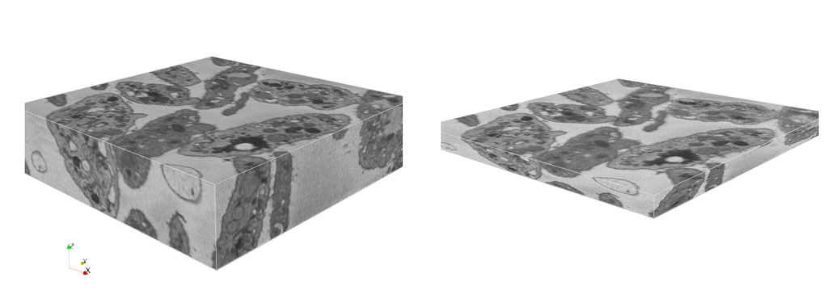

```python
Image(filename='./img/sr_3d.png')
```

(left) Platelet dataset superresolved via SRCNN. (right) original dataset

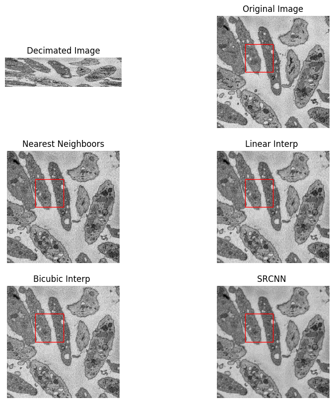

```python
Image(filename='./img/result_figs.png')
```

Comparing image quality between different SR methods. They look fairly similar from a zoomed-out view. Volume reproduced from the SRCNN has a noticeable reduction in noise.

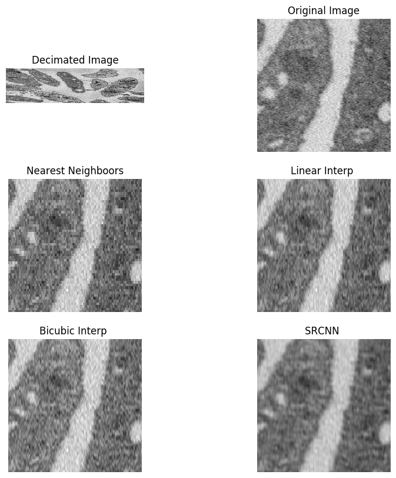

```python
Image(filename='./img/result_figs_zoom.png')
```

Zoomed in versions of the platelet images. It is clear the the SRCNN is more blurred than the other SR methods, bit it more natural looking and doesn't have artifacts from SR that we see in the other methods.

## Next Steps

The next steps for the SR project are to develop 3D versions of the WDSRA, WDSRB and perhaps the FSRCNN architectures to find the best method for 3D axial superresolution for EM.